# Project: Investigate a Dataset (No-show appointments)

- Introduction
- Data Wrangling
- Exploratory Data Analysis
- Conclusions

## Introduction

> **No-show Appointment Dataset**: In this Dataset contains patients information from 100k + medical appointments in Brazil. The data contains a number of possible datapoints that may indicate wheather or not a patient will show up for an appointment.

> The original dataset [here](https://www.kaggle.com/joniarroba/noshowappointments)

## Questions to be investiagted

1. Overall Number of patients attendence to appointments?
2. Gender wise of show vs no- show patients?

```python
#import libraries
import pandas as pd
import numpy as np
import matplotlib.pyplot as plt
import seaborn as sns
import datetime as dt
from datetime import timedelta
%matplotlib inline
```

## Data Wrangling

```python
# load no-show appointments
no_show = pd.read_csv('no-show appointments.csv')
#view
no_show.head()
```

|  | PatientId | AppointmentID | Gender | ScheduledDay | AppointmentDay | Age | Neighbourhood | Scholarship | Hipertension | Diabetes | Alcoholism | Handcap | SMS_received | No-show |
| --- | --- | --- | --- | --- | --- | --- | --- | --- | --- | --- | --- | --- | --- | --- |
| 0 | 2.987250e+13 | 5642903 | F | 2016-04-29T18:38:08Z | 2016-04-29T00:00:00Z | 62 | JARDIM DA PENHA | 0 | 1 | 0 | 0 | 0 | 0 | No |
| 1 | 5.589978e+14 | 5642503 | M | 2016-04-29T16:08:27Z | 2016-04-29T00:00:00Z | 56 | JARDIM DA PENHA | 0 | 0 | 0 | 0 | 0 | 0 | No |
| 2 | 4.262962e+12 | 5642549 | F | 2016-04-29T16:19:04Z | 2016-04-29T00:00:00Z | 62 | MATA DA PRAIA | 0 | 0 | 0 | 0 | 0 | 0 | No |
| 3 | 8.679512e+11 | 5642828 | F | 2016-04-29T17:29:31Z | 2016-04-29T00:00:00Z | 8 | PONTAL DE CAMBURI | 0 | 0 | 0 | 0 | 0 | 0 | No |
| 4 | 8.841186e+12 | 5642494 | F | 2016-04-29T16:07:23Z | 2016-04-29T00:00:00Z | 56 | JARDIM DA PENHA | 0 | 1 | 1 | 0 | 0 | 0 | No |

```python
# number of rows and columns
no_show.shape
```

```
(110527, 14)
```

```python
#information of no_show data
no_show.info() # no null values
```

```
<class 'pandas.core.frame.DataFrame'>
RangeIndex: 110527 entries, 0 to 110526
Data columns (total 14 columns):
PatientId         110527 non-null float64
AppointmentID     110527 non-null int64
Gender            110527 non-null object
ScheduledDay      110527 non-null object
AppointmentDay    110527 non-null object
Age               110527 non-null int64
Neighbourhood     110527 non-null object
Scholarship       110527 non-null int64
Hipertension      110527 non-null int64
Diabetes          110527 non-null int64
Alcoholism        110527 non-null int64
Handcap           110527 non-null int64
SMS_received      110527 non-null int64
No-show           110527 non-null object
dtypes: float64(1), int64(8), object(5)
memory usage: 11.8+ MB
```

```python
#check null values
no_show.isnull().sum() # zero null values
```

```
PatientId         0
AppointmentID     0
Gender            0
ScheduledDay      0
AppointmentDay    0
Age               0
Neighbourhood     0
Scholarship       0
Hipertension      0
Diabetes          0
Alcoholism        0
Handcap           0
SMS_received      0
No-show           0
dtype: int64
```

```python
# check duplicate values
no_show.duplicated().sum()
```

```
0
```

```python
# information of dataset
no_show.describe()
```

|  | PatientId | AppointmentID | Age | Scholarship | Hipertension | Diabetes | Alcoholism | Handcap | SMS_received |
| --- | --- | --- | --- | --- | --- | --- | --- | --- | --- |
| count | 1.105270e+05 | 1.105270e+05 | 110527.000000 | 110527.000000 | 110527.000000 | 110527.000000 | 110527.000000 | 110527.000000 | 110527.000000 |
| mean | 1.474963e+14 | 5.675305e+06 | 37.088874 | 0.098266 | 0.197246 | 0.071865 | 0.030400 | 0.022248 | 0.321026 |
| std | 2.560949e+14 | 7.129575e+04 | 23.110205 | 0.297675 | 0.397921 | 0.258265 | 0.171686 | 0.161543 | 0.466873 |
| min | 3.921784e+04 | 5.030230e+06 | -1.000000 | 0.000000 | 0.000000 | 0.000000 | 0.000000 | 0.000000 | 0.000000 |
| 25% | 4.172614e+12 | 5.640286e+06 | 18.000000 | 0.000000 | 0.000000 | 0.000000 | 0.000000 | 0.000000 | 0.000000 |
| 50% | 3.173184e+13 | 5.680573e+06 | 37.000000 | 0.000000 | 0.000000 | 0.000000 | 0.000000 | 0.000000 | 0.000000 |
| 75% | 9.439172e+13 | 5.725524e+06 | 55.000000 | 0.000000 | 0.000000 | 0.000000 | 0.000000 | 0.000000 | 1.000000 |
| max | 9.999816e+14 | 5.790484e+06 | 115.000000 | 1.000000 | 1.000000 | 1.000000 | 1.000000 | 4.000000 | 1.000000 |

[figure not shown]

```python
no_show.hist(figsize=(15,14));
```

### Observations

Age: There are many very young people in the diabetes but in general the patient age is distributed evenly and the number of patients goes drasticly down for patients older than sixty years.

Alcoholism : Most of the patients are not alchololics.

Diabetes : Most of them are not diabetes patients but more than alcoholics.

Hypertensions: Most of them don't have it.

```python
#number of unique values
no_show.nunique()
```

```
PatientId          62299
AppointmentID     110527
Gender                 2
ScheduledDay      103549
AppointmentDay        27
Age                  104
Neighbourhood         81
Scholarship            2
Hipertension           2
Diabetes               2
Alcoholism             2
Handcap                5
SMS_received           2
No-show                2
dtype: int64
```

### Data Cleaning

```python
#rename columns
no_show.rename(columns = {'Handcap' : 'Handicap', 'Hipertension' : 'Hypertension', 'No-show' : 'noshow'}, inplace = True)
#verify
no_show.info()
```

```
<class 'pandas.core.frame.DataFrame'>
RangeIndex: 110527 entries, 0 to 110526
Data columns (total 14 columns):
PatientId         110527 non-null float64
AppointmentID     110527 non-null int64
Gender            110527 non-null object
ScheduledDay      110527 non-null object
AppointmentDay    110527 non-null object
Age               110527 non-null int64
Neighbourhood     110527 non-null object
Scholarship       110527 non-null int64
Hypertension      110527 non-null int64
Diabetes          110527 non-null int64
Alcoholism        110527 non-null int64
Handicap          110527 non-null int64
SMS_received      110527 non-null int64
noshow            110527 non-null object
dtypes: float64(1), int64(8), object(5)
memory usage: 11.8+ MB
```

```python
#extract yyyy-mm-dd
no_show['ScheduledDay'] = no_show['ScheduledDay'].str[0:10]
no_show['AppointmentDay'] = no_show['AppointmentDay'].str[0:10]
no_show.head()
```

|  | PatientId | AppointmentID | Gender | ScheduledDay | AppointmentDay | Age | Neighbourhood | Scholarship | Hypertension | Diabetes | Alcoholism | Handicap | SMS_received | noshow |
| --- | --- | --- | --- | --- | --- | --- | --- | --- | --- | --- | --- | --- | --- | --- |
| 0 | 2.987250e+13 | 5642903 | F | 2016-04-29 | 2016-04-29 | 62 | JARDIM DA PENHA | 0 | 1 | 0 | 0 | 0 | 0 | No |
| 1 | 5.589978e+14 | 5642503 | M | 2016-04-29 | 2016-04-29 | 56 | JARDIM DA PENHA | 0 | 0 | 0 | 0 | 0 | 0 | No |
| 2 | 4.262962e+12 | 5642549 | F | 2016-04-29 | 2016-04-29 | 62 | MATA DA PRAIA | 0 | 0 | 0 | 0 | 0 | 0 | No |
| 3 | 8.679512e+11 | 5642828 | F | 2016-04-29 | 2016-04-29 | 8 | PONTAL DE CAMBURI | 0 | 0 | 0 | 0 | 0 | 0 | No |
| 4 | 8.841186e+12 | 5642494 | F | 2016-04-29 | 2016-04-29 | 56 | JARDIM DA PENHA | 0 | 1 | 1 | 0 | 0 | 0 | No |

```python
#convert the type of days from string to datetime64
no_show_ScheduledDay = pd.to_datetime(no_show['ScheduledDay'])
type(no_show_ScheduledDay[0])
```

```
pandas._libs.tslibs.timestamps.Timestamp
```

```python
no_show_AppointmentDay = pd.to_datetime(no_show['AppointmentDay'])
type(no_show_AppointmentDay[0])
```

```
pandas._libs.tslibs.timestamps.Timestamp
```

```python
#convert the date into the weekday
no_show_weekdays = pd.to_datetime(no_show['AppointmentDay']).dt.weekday.rename("weekday")
```

```python
#calculate the days btw the two days
no_show_duration = (no_show_AppointmentDay - no_show_ScheduledDay).dt.days.rename('Duration')
```

```python
#add columns
no_show = pd.concat([no_show, no_show_weekdays, no_show_duration], axis = 1)
```

```python
no_show.head()
```

|  | PatientId | AppointmentID | Gender | ScheduledDay | AppointmentDay | Age | Neighbourhood | Scholarship | Hypertension | Diabetes | Alcoholism | Handicap | SMS_received | noshow | weekday | Duration |
| --- | --- | --- | --- | --- | --- | --- | --- | --- | --- | --- | --- | --- | --- | --- | --- | --- |
| 0 | 2.987250e+13 | 5642903 | F | 2016-04-29 | 2016-04-29 | 62 | JARDIM DA PENHA | 0 | 1 | 0 | 0 | 0 | 0 | No | 4 | 0 |
| 1 | 5.589978e+14 | 5642503 | M | 2016-04-29 | 2016-04-29 | 56 | JARDIM DA PENHA | 0 | 0 | 0 | 0 | 0 | 0 | No | 4 | 0 |
| 2 | 4.262962e+12 | 5642549 | F | 2016-04-29 | 2016-04-29 | 62 | MATA DA PRAIA | 0 | 0 | 0 | 0 | 0 | 0 | No | 4 | 0 |
| 3 | 8.679512e+11 | 5642828 | F | 2016-04-29 | 2016-04-29 | 8 | PONTAL DE CAMBURI | 0 | 0 | 0 | 0 | 0 | 0 | No | 4 | 0 |
| 4 | 8.841186e+12 | 5642494 | F | 2016-04-29 | 2016-04-29 | 56 | JARDIM DA PENHA | 0 | 1 | 1 | 0 | 0 | 0 | No | 4 | 0 |

```python
no_show[no_show.Duration < 0].count()
```

```
PatientId         5
AppointmentID     5
Gender            5
ScheduledDay      5
AppointmentDay    5
Age               5
Neighbourhood     5
Scholarship       5
Hypertension      5
Diabetes          5
Alcoholism        5
Handicap          5
SMS_received      5
noshow            5
weekday           5
Duration          5
dtype: int64
```

```python
no_show[no_show.Duration >= 0].count()
```

```
PatientId         110522
AppointmentID     110522
Gender            110522
ScheduledDay      110522
AppointmentDay    110522
Age               110522
Neighbourhood     110522
Scholarship       110522
Hypertension      110522
Diabetes          110522
Alcoholism        110522
Handicap          110522
SMS_received      110522
noshow            110522
weekday           110522
Duration          110522
dtype: int64
```

```python
#Age
no_show_age = no_show['Age'].unique()
no_show_age.sort()
```

```python
no_show['Age'].value_counts()
```

```
 0      3539
 1      2273
 52     1746
 49     1652
 53     1651
 56     1635
 38     1629
 59     1624
 2      1618
 50     1613
 57     1603
 36     1580
 51     1567
 19     1545
 39     1536
```

[output cut: 47 more lines]

```python
no_show = no_show[(no_show.Age >= 0) & (no_show.Age < 98)]
```

```python
#Handicap
##count
no_show['Handicap'].value_counts()
```

```
0    108273
1      2036
2       183
3        13
4         3
Name: Handicap, dtype: int64
```

```python
#modify
no_show.loc[no_show.Handicap > 1, 'Handicap'] = 1
```

```python
no_show['Handicap'].value_counts()
```

```
0    108273
1      2235
Name: Handicap, dtype: int64
```

```python
#check the dataset
no_show.nunique()
```

```
PatientId          62286
AppointmentID     110508
Gender                 2
ScheduledDay         111
AppointmentDay        27
Age                   98
Neighbourhood         81
Scholarship            2
Hypertension           2
Diabetes               2
Alcoholism             2
Handicap               2
SMS_received           2
noshow                 2
weekday                6
Duration             131
dtype: int64
```

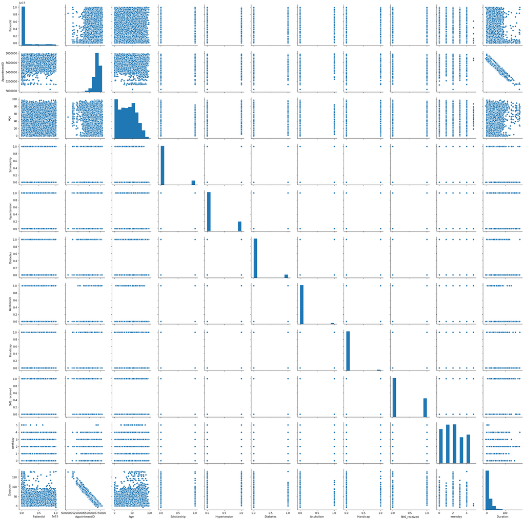

```python
sns.pairplot(no_show);
```

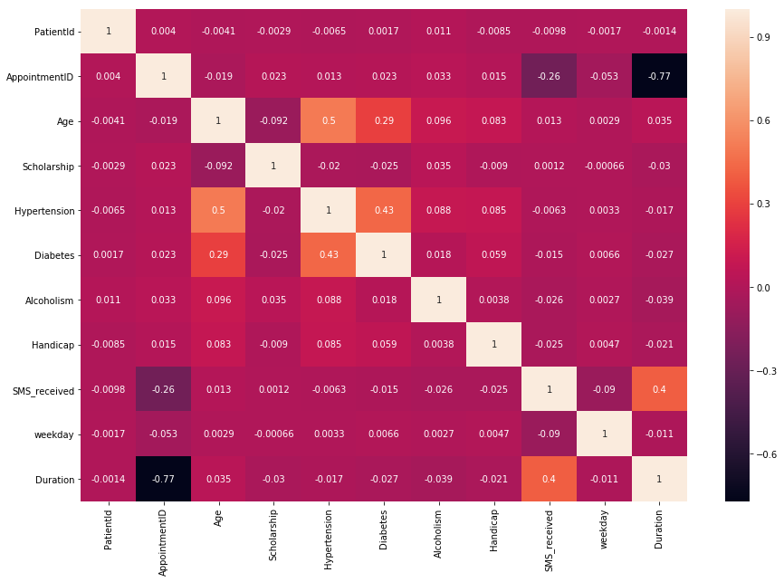

```python
fig, ax =plt.subplots(figsize=(15,10))
sns.heatmap(no_show.corr(), ax=ax, annot=True);
```

```python
no_show.Gender.describe()
```

```
count     110508
unique         2
top            F
freq       71824
Name: Gender, dtype: object
```

```python
#ScheduledDay
print("unique values in 'ScheduledDay' = {}".format(no_show.ScheduledDay.unique()))
```

```
unique values in 'ScheduledDay' = ['2016-04-29' '2016-04-27' '2016-04-26' '2016-04-28' '2016-04-25'
 '2016-04-20' '2016-03-31' '2016-04-19' '2016-04-06' '2016-04-18'
 '2016-04-11' '2016-04-12' '2016-04-15' '2016-04-01' '2016-04-05'
 '2016-04-08' '2016-04-14' '2016-04-13' '2016-04-07' '2016-03-17'
 '2016-03-30' '2016-03-29' '2016-03-18' '2016-03-28' '2016-03-04'
 '2016-03-15' '2016-03-14' '2016-03-21' '2016-03-23' '2016-03-22'
 '2016-03-16' '2016-03-10' '2016-02-29' '2016-03-08' '2016-03-07'
 '2016-02-24' '2016-02-22' '2016-01-29' '2016-02-23' '2016-02-05'
 '2016-02-11' '2016-02-02' '2016-01-05' '2016-01-11' '2016-02-26'
 '2016-02-19' '2016-02-17' '2016-03-03' '2016-03-02' '2016-03-09'
 '2016-03-01' '2016-03-19' '2016-03-11' '2016-02-16' '2016-02-25'
 '2016-04-09' '2016-05-24' '2016-05-25' '2016-05-31' '2016-05-17'
 '2016-05-30' '2016-05-12' '2016-05-19' '2016-05-10' '2016-05-02'
 '2016-05-16' '2016-05-04' '2016-05-13' '2016-05-20' '2016-05-05'
 '2016-05-18' '2016-05-06' '2016-05-09' '2016-05-03' '2016-05-11'
 '2015-11-10' '2016-02-18' '2016-02-03' '2016-01-14' '2016-01-21'
 '2016-01-28' '2016-02-01' '2015-12-14' '2015-12-08' '2016-01-07'
 '2016-04-30' '2016-04-16' '2016-02-04' '2015-12-03' '2016-01-04'
 '2016-01-13' '2016-02-12' '2016-01-20' '2016-01-22' '2016-01-25'
 '2016-01-27' '2016-01-19' '2016-02-15' '2016-05-14' '2016-05-07'
 '2016-06-02' '2016-06-03' '2016-06-01' '2016-06-06' '2016-06-07'
 '2016-06-08' '2016-06-04' '2016-01-26' '2015-12-07' '2015-12-15'
 '2016-03-05']
```

```python
#AppointmentDay
print("unique values in 'AppointmentDay' = {}".format(no_show.AppointmentDay.unique()))
```

```
unique values in 'AppointmentDay' = ['2016-04-29' '2016-05-03' '2016-05-10' '2016-05-17' '2016-05-24'
 '2016-05-31' '2016-05-02' '2016-05-30' '2016-05-16' '2016-05-04'
 '2016-05-19' '2016-05-12' '2016-05-06' '2016-05-20' '2016-05-05'
 '2016-05-13' '2016-05-09' '2016-05-25' '2016-05-11' '2016-05-18'
 '2016-05-14' '2016-06-02' '2016-06-03' '2016-06-06' '2016-06-07'
 '2016-06-01' '2016-06-08']
```

## Exploratory Data Analysis

### Gender

```python
no_show.Gender.describe()
```

```
count     110508
unique         2
top            F
freq       71824
Name: Gender, dtype: object
```

```python
noshow_gender = no_show['Gender'].value_counts()
```

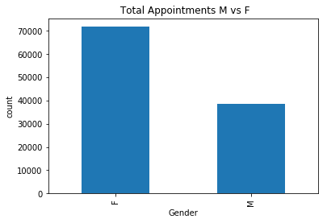

```python
noshow_gender.plot(kind = 'bar', title = ' Total Appointments M vs F');
plt.xlabel('Gender');
plt.ylabel('count');
```

## Research Question 1 (Overall Number of patients attendence to appointments?)

```python
df = no_show.groupby('noshow')['noshow'].agg(['count'])
df.reset_index(inplace=True)
df.columns = ['appt_status', 'total']
df.iloc[1,0] = "Show"
df.iloc[0,0] = "No show"
```

```python
show_pro = df.iloc[0,1]/ (df.iloc[0,1] + df.iloc[1,1])
noshow_pro = df.iloc[1,1]/(df.iloc[0,1] + df.iloc[1,1])
```

```python
df['Propotion'] = [show_pro, noshow_pro]
df.head()
```

[output not shown]

[figure not shown]

```python
#visualization
labels = ['No shows', 'Shows']
colors = ['Orange','Green']
size = [show_pro, noshow_pro]
explode = (0, 0.1)
plt.pie(size, colors = colors, explode = explode, labels = labels, autopct ='%1.1f%%')
plt.title('Appointments Shows vs No Shows')
plt.axis('equal')
plt.show()
```

Overall patients attendence to appointments

# Research Question 2 ( Gender wise of show vs no- show patients?)

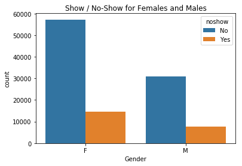

```
Out of 71824 appointments made by females, 14590 were missed with the ratio of 20%.
Out of 38684 appointments made by males, 7725 were missed with the ratio of 20%.
```

```python
all_appoint_f = len(no_show.loc[no_show['Gender'] == "F"])
all_appoint_m = len(no_show.loc[no_show['Gender'] == "M"])

missed_appoint_f = len(no_show.query('noshow == "Yes" and Gender == "F"'))
missed_appoint_m = len(no_show.loc[(no_show['Gender'] == "M") & (no_show['noshow'] == "Yes")])

missed_ratio_f = int(round(missed_appoint_f/all_appoint_f*100))
missed_ratio_m = int(round(missed_appoint_m/all_appoint_m*100))

ax = sns.countplot(x=no_show.Gender, hue=no_show.noshow, data=df)
ax.set_title("Show / No-Show for Females and Males")
x_ticks_labels=['Female', 'Male']
plt.show();

print('Out of {} appointments made by females, {} were missed with the ratio of {}%.'.format(all_appoint_f, missed_appoint_f, missed_ratio_f))
print('Out of {} appointments made by males, {} were missed with the ratio of {}%.'.format(all_appoint_m, missed_appoint_m, missed_ratio_m))
```

## Top patients with most appointments

```python
no_show.PatientId.value_counts().iloc[0:10]
```

```
8.221459e+14    88
9.963767e+10    84
2.688613e+13    70
3.353478e+13    65
7.579746e+13    62
2.584244e+11    62
8.713749e+14    62
6.264199e+12    62
6.684488e+13    57
8.722785e+11    55
Name: PatientId, dtype: int64
```

# Limitations

1. Missing some features that may useful to get more of it. for example, patient medical condition and we have some illogical data such as patients age with 0.
2. The analysis is limited to trends and only shows value distributions, causations can't be drawn. Statistical tests and more thorough data segmentations would be required.
3. The dataset explored in this analysis was over a six month period. Data for a longer would provide insight into how seasonality and holidays imoact show rates.
4. The Patients with repeat no-shows would be a good cohort to remove from the analysis to understand environment or health factors influencing no-shows. This was not done but could improve the integrity of the investigation.
5. Overlaying external data sources on to this dataset such as weather, traffic or geographic data and allow us to better understand influences on no-shows rates. At present, the analysis is limited to general correlations.

## Conclusions

I manage a few problems in dataset like unifying names, adding new features based on existing data and also investigated most of independent variables inthe dataset. The data should be investigate futhur with more advanced statistical analysis to potentially reveal new insights and correlations.